# Analyse des données

2023-01-19

## Import de packages utiles

```r
library(FactoMineR)
library(factoextra)
library(CASdatasets)
library(tidyverse)
library(MASS)
```

```r
library(knitr)
library(ggplot2)
library(cowplot)
library(reshape2)
library(dplyr)
library(GGally)
library(corrplot)
library(carData)
library(car)
library(questionr)
library(multcomp)
library(dplyr)
library(leaps)
library(TeachingDemos)
library(FactoMineR)
library(factoextra)
library(ROCR)
library(plotROC)
```

## Documentation et import du dataset

```r
?CASdatasets #ouvre l'aide pour comprendre le dataset
```

```
## démarrage du serveur d'aide httpd ... fini
```

```r
data(freMPL5)

summary(freMPL5)
```

```
##     Exposure         LicAge      RecordBeg            RecordEnd
##  Min.   :0.001   Min.   : 24   Min.   :2004-01-01   Min.   :2004-01-02
##  1st Qu.:0.170   1st Qu.:229   1st Qu.:2004-01-01   1st Qu.:2004-05-01
##  Median :0.403   Median :355   Median :2004-04-15   Median :2004-07-18
##  Mean   :0.423   Mean   :350   Mean   :2004-05-07   Mean   :2004-07-20
##  3rd Qu.:0.666   3rd Qu.:463   3rd Qu.:2004-08-11   3rd Qu.:2004-10-14
##  Max.   :1.000   Max.   :844   Max.   :2004-12-31   Max.   :2004-12-31
##                                                     NA's   :12818
##     Gender       MariStat       SocioCateg                      VehUsage
##  Female: 8856   Alone: 3461   CSP50  :12385   Private               : 8576
##  Male  :17144   Other:22539   CSP60  : 5646   Private+trip to office:12163
##                               CSP55  : 3247   Professional          : 4299
##                               CSP1   :  960   Professional run      :  962
##                               CSP66  :  672
##                               CSP42  :  655
##                               (Other): 2435
##     DrivAge        HasKmLimit       ClaimAmount       ClaimNbResp
##  Min.   :20.00   Min.   :0.00000   Min.   :-1842.0   Min.   :0.0000
##  1st Qu.:39.00   1st Qu.:0.00000   1st Qu.:    0.0   1st Qu.:0.0000
##  Median :51.00   Median :0.00000   Median :    0.0   Median :0.0000
##  Mean   :50.45   Mean   :0.07462   Mean   :  204.9   Mean   :0.2663
##  3rd Qu.:61.00   3rd Qu.:0.00000   3rd Qu.:    0.0   3rd Qu.:0.0000
##  Max.   :95.00   Max.   :1.00000   Max.   :95151.0   Max.   :4.0000
##
##  ClaimNbNonResp   ClaimNbParking    ClaimNbFireTheft  ClaimNbWindscreen
##  Min.   :0.0000   Min.   :0.00000   Min.   :0.00000   Min.   :0.000
##  1st Qu.:0.0000   1st Qu.:0.00000   1st Qu.:0.00000   1st Qu.:0.000
##  Median :0.0000   Median :0.00000   Median :0.00000   Median :0.000
##  Mean   :0.3218   Mean   :0.08265   Mean   :0.07638   Mean   :0.418
##  3rd Qu.:1.0000   3rd Qu.:0.00000   3rd Qu.:0.00000   3rd Qu.:1.000
##  Max.   :7.0000   Max.   :4.00000   Max.   :3.00000   Max.   :8.000
##
##     OutUseNb         RiskArea        BonusMalus        ClaimInd
##  Min.   :0.0000   Min.   : 1.000   Min.   : 50.00   Min.   :0.000
##  1st Qu.:0.0000   1st Qu.: 6.000   1st Qu.: 50.00   1st Qu.:0.000
##  Median :0.0000   Median : 7.000   Median : 50.00   Median :0.000
##  Mean   :0.2243   Mean   : 7.845   Mean   : 57.78   Mean   :0.093
##  3rd Qu.:0.0000   3rd Qu.:10.000   3rd Qu.: 60.00   3rd Qu.:0.000
##  Max.   :5.0000   Max.   :13.000   Max.   :185.00   Max.   :1.000
##
```

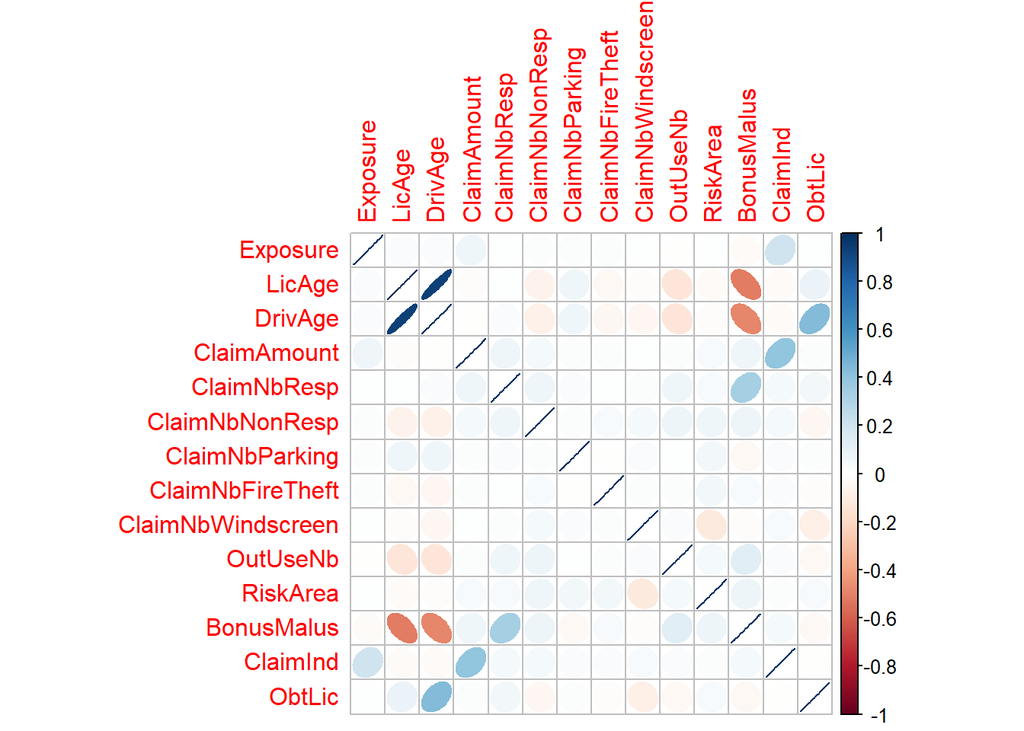

```r
#Cette nouvelle covariable sera présentée plus tard
freMPL5$ObtLic <- ceiling(freMPL5$DrivAge - freMPL5$LicAge/12)

x <- freMPL5[, c(1,2,9,11,12,13,14,15,16,17,18,19,20, 21)]
corrplot(round(cor(x),2),method="ellipse")
```

freMPL veut dire French Motor Personal Line datasets. On utilisera le dataset 5 qui contient environ 26000 contrats de l’annee 2004.

On a ici un premier résumé des variables avec des premières corrélations.

On voit des fortes corrélations en valeur absolue entre BonusMalus, DrivAge et LicAge. Cela peut facilement se comprendre car l’âge du conducteur et le temps écoulé depuis qu’il a obtenu son permis sont souvent fortement lié. On pourrait d’ailleurs éventuellement créer une variable pour connaitre l’âge du conducteur lorsqu’il a obtenu le permis.

On remarque que certaines variables sont numériques au lieu d’être considérées comme des facteurs. Nous allons donc les changer :

```r
freMPL5$HasKmLimit <- factor(freMPL5$HasKmLimit)
freMPL5$ClaimInd <- factor(freMPL5$ClaimInd)
freMPL5$RiskArea <- factor(freMPL5$RiskArea)
freMPL5$ClaimNbResp <- factor(freMPL5$ClaimNbResp)
freMPL5$ClaimNbNonResp <- factor(freMPL5$ClaimNbNonResp)
freMPL5$ClaimNbParking <- factor(freMPL5$ClaimNbParking)
freMPL5$ClaimNbFireTheft <- factor(freMPL5$ClaimNbFireTheft)
freMPL5$ClaimNbWindscreen <- factor(freMPL5$ClaimNbWindscreen)
freMPL5$OutUseNb <- factor(freMPL5$OutUseNb)
```

### Coefficient de bonus-malus

Pour le coefficient de bonus-malus, il commence à 1 et peut descendre jusqu’à 0.5 si le conducteur n’a pas d’accidents responsables ou semi-responsables. A l’inverse, en cas d’accidents responsables, le coefficient augmente et peut atteindre jusqu’à 3.5. Dans le jeu de données, toutes les valeurs sont multipliées par 100 ce qui ne posera aucun problème dans le cas de nos modèles. Cependant, si on veut voir l’impact linéaire du coefficient de bonus-malus, il pourrait être intéressant de revoir son échelle en retranchant 100 par exemple à la variable. C’est pour cela qu’il y a une corrélation assez importante entre BonusMalus et ClaimNbResp.

Dans notre jeu de données, la valeur maximale est 1.85. Nous n’avons donc aucune information sur des éventuels assurés possédant un malus supérieur. Cela pourra donc être compliqué de prédire les primes d’assurances pour ce genre d’assurés. De manière générale, ici on a princialement des bons conducteurs puisque la médianne vaut 0.5 et le 3eme quartile 0.6 et 95% des assurés sont en dessous de 0.90.

```r
summary(freMPL5$BonusMalus)
```

```
##    Min. 1st Qu.  Median    Mean 3rd Qu.    Max.
##   50.00   50.00   50.00   57.78   60.00  185.00
```

```r
quantile(freMPL5$BonusMalus, seq(0,1,0.05))
```

```
##   0%   5%  10%  15%  20%  25%  30%  35%  40%  45%  50%  55%  60%  65%  70%  75%
##   50   50   50   50   50   50   50   50   50   50   50   50   50   51   55   60
##  80%  85%  90%  95% 100%
##   65   72   80   90  185
```

##### Etude par rapport à la sinistralité

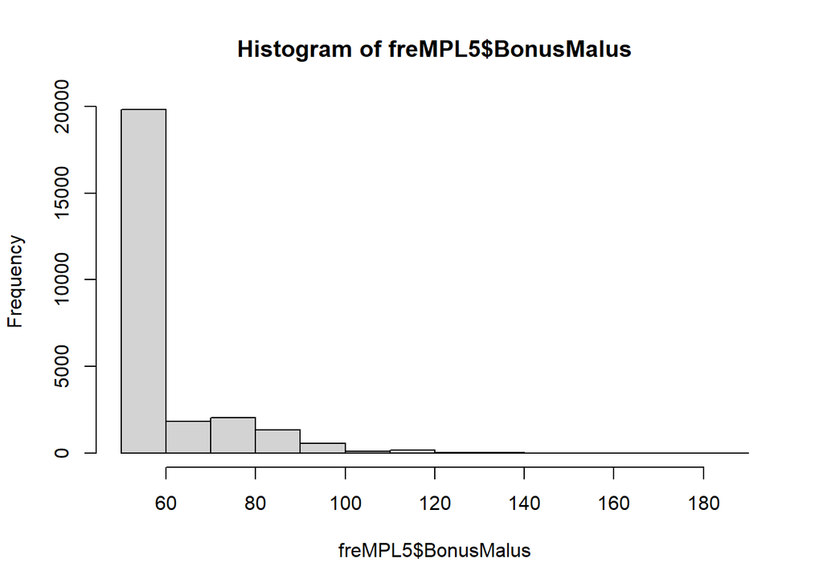

```r
hist(freMPL5$BonusMalus)
```

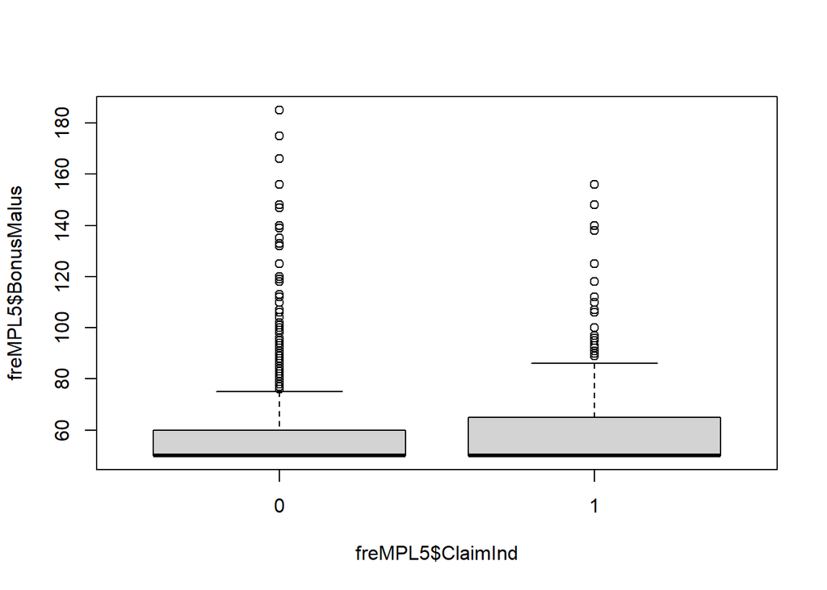

```r
boxplot(freMPL5$BonusMalus ~ freMPL5$ClaimInd)
```

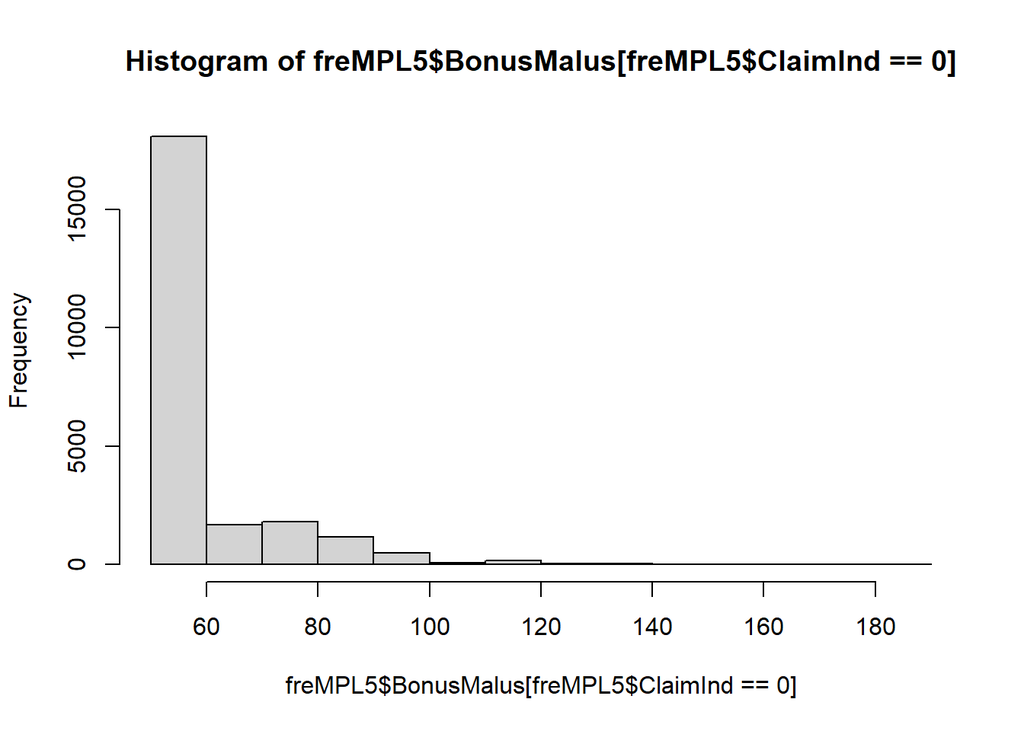

```r
hist(freMPL5$BonusMalus[freMPL5$ClaimInd == 0])
```

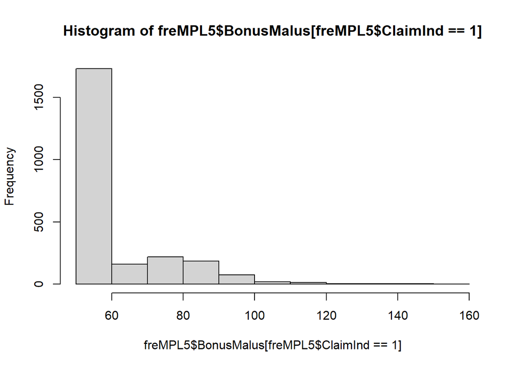

```r
hist(freMPL5$BonusMalus[freMPL5$ClaimInd == 1])
```

C’est surtout le boxplot qui permet de conclure à un lien car ceux qui ont à réclamer de l’argent ont en moyenne un Bonus plus faible que les autres.

##### Etude par rapport au coût

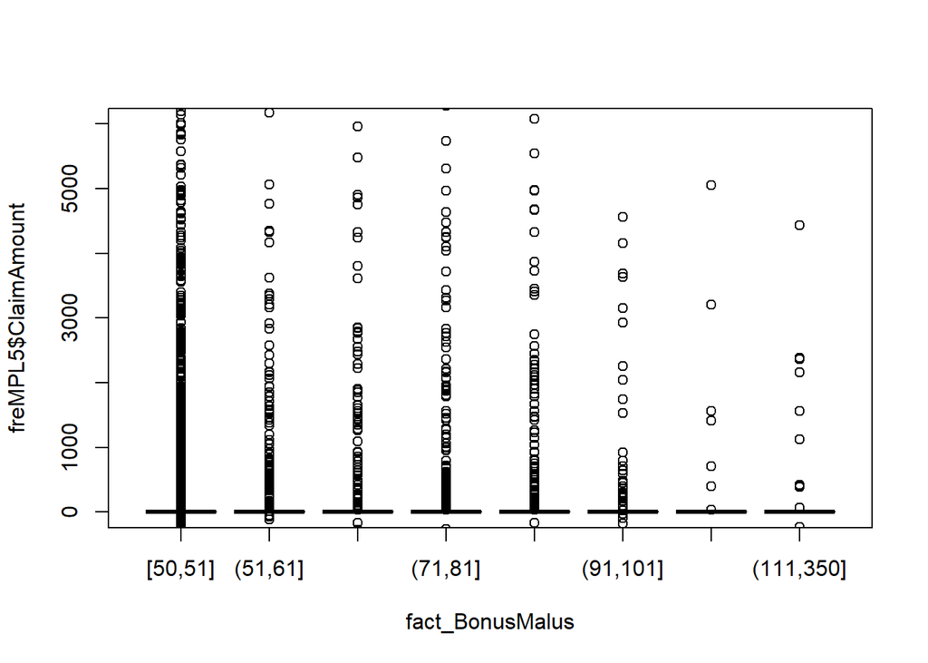

```r
fact_BonusMalus <- cut(freMPL5$BonusMalus, c(50,seq(51,120,10),350), include.lowest = TRUE)
boxplot(freMPL5$ClaimAmount ~ fact_BonusMalus, ylim=c(0,6000))
```

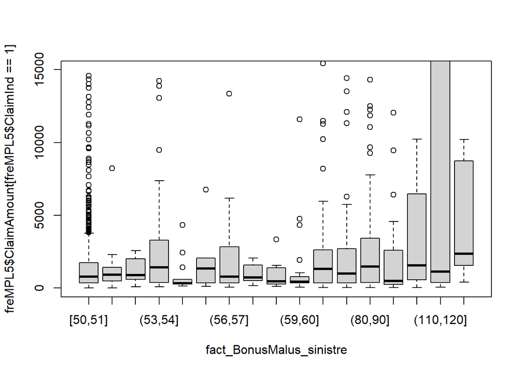

```r
fact_BonusMalus_sinistre <- cut(freMPL5$BonusMalus[freMPL5$ClaimInd == 1], c(seq(50,59,1),seq(60,120,10),350), include.lowest = TRUE)
boxplot(freMPL5$ClaimAmount[freMPL5$ClaimInd == 1] ~ fact_BonusMalus_sinistre, ylim=c(0,15000))
```

Le premier graphique n’étant pas interprétable, nous avons créé le deuxieme qui semble nous donner une certaine tendance : plus le coefficient de malus est élevé et plus le coût moyen augmente.

### Etude de la variable d’âge (DrivAge)

```r
summary(freMPL5$DrivAge)
```

```
##    Min. 1st Qu.  Median    Mean 3rd Qu.    Max.
##   20.00   39.00   51.00   50.45   61.00   95.00
```

##### Etude par rapport à la sinistralité

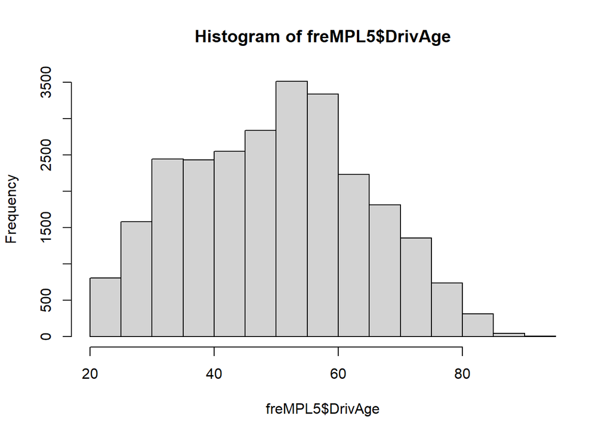

```r
hist(freMPL5$DrivAge)
```

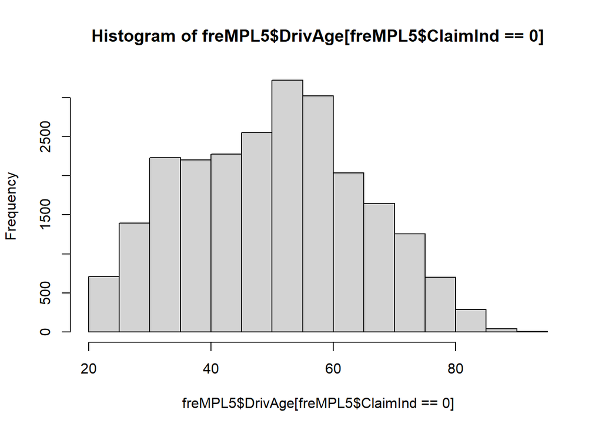

```r
hist(freMPL5$DrivAge[freMPL5$ClaimInd == 0])
```

```r
summary(freMPL5$DrivAge[freMPL5$ClaimInd == 0])
```

```
##    Min. 1st Qu.  Median    Mean 3rd Qu.    Max.
##   20.00   39.00   51.00   50.61   61.00   95.00
```

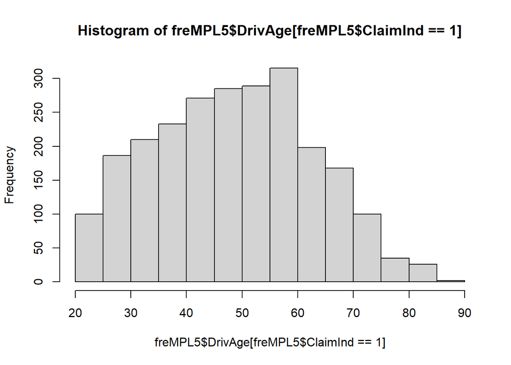

```r
hist(freMPL5$DrivAge[freMPL5$ClaimInd == 1])
```

```r
summary(freMPL5$DrivAge[freMPL5$ClaimInd == 1])
```

```
##    Min. 1st Qu.  Median    Mean 3rd Qu.    Max.
##   20.00   38.00   49.00   48.92   59.00   88.00
```

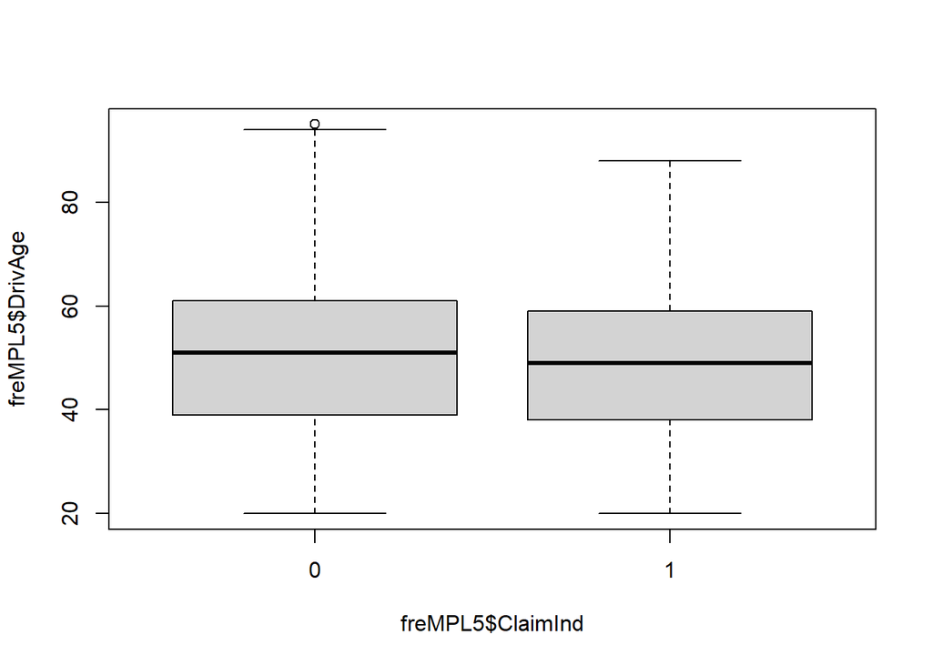

```r
boxplot(freMPL5$DrivAge ~ freMPL5$ClaimInd)
```

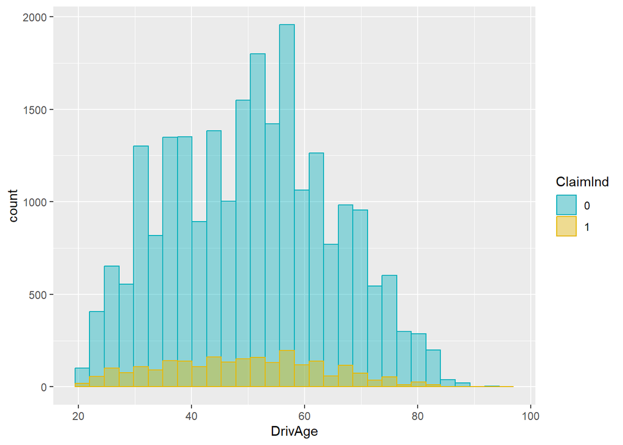

```r
ggplot(freMPL5, aes(x = DrivAge)) +
  geom_histogram(aes(color = ClaimInd, fill = ClaimInd),
                position = "identity", bins = 30, alpha = 0.4) +
  scale_color_manual(values = c("#00AFBB", "#E7B800")) +
  scale_fill_manual(values = c("#00AFBB", "#E7B800"))
```

L’âge du conducteur semble donc avoir un impact dans le risque d’avoir un sinistre (plus on est jeune, et plus on risque de coûter de l’argent à l’assurance). En effet, la proportion de 35-50 ans est très forte mais il n’y a pas beaucoup de sinistres pour autant comparé aux 20-30 ans.

##### Etude par rapport au coût

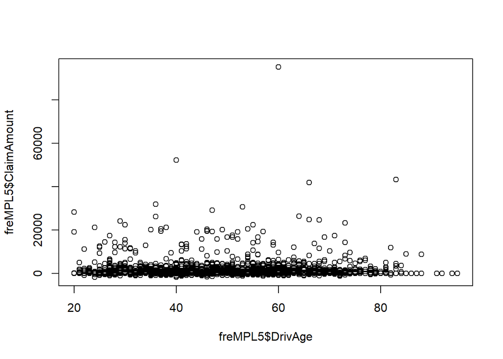

```r
plot(freMPL5$ClaimAmount ~ freMPL5$DrivAge)
```

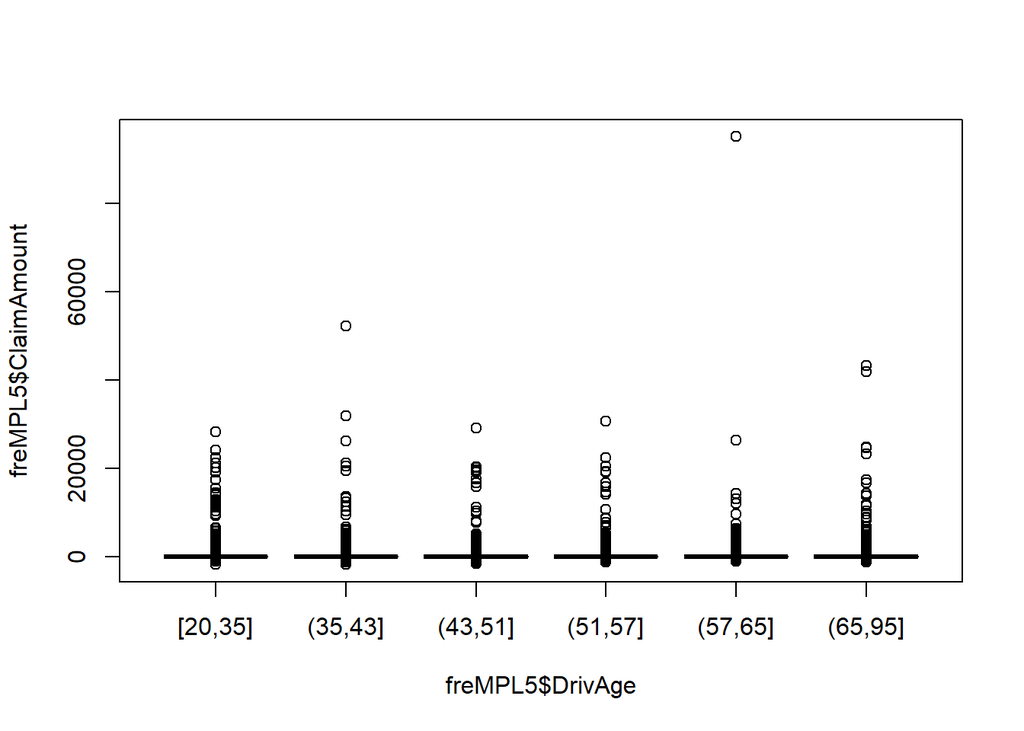

```r
freMPL5$DrivAge <- cut(freMPL5$DrivAge, quantile(freMPL5$DrivAge, probs = seq(0,1,1/6)), include.lowest = TRUE)
boxplot(freMPL5$ClaimAmount ~ freMPL5$DrivAge)
```

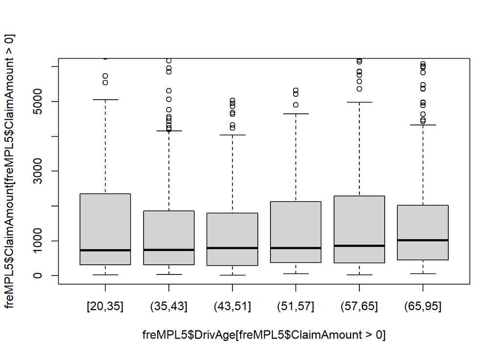

```r
boxplot(freMPL5$ClaimAmount[freMPL5$ClaimAmount>0] ~ freMPL5$DrivAge[freMPL5$ClaimAmount>0], ylim=c(0,6000))
```

On observe donc un risque accru pour les jeunes conducteurs mais on remarque aussi que le risque augmente de nouveau après 50 ans (cela pourrait correspondre au moment où les enfants sont en âge de conduire sur le véhicule des parents).

### Etude de la variable d’ancienneté du permis (LicAge)

Cette variable est exprimée en mois. Nous rappelons qu’elle est très corrélée avec DrivAge et Bonus-Malus.

```r
summary(freMPL5$LicAge)
```

```
##    Min. 1st Qu.  Median    Mean 3rd Qu.    Max.
##      24     229     355     350     463     844
```

##### Etude par rapport à la sinistralité

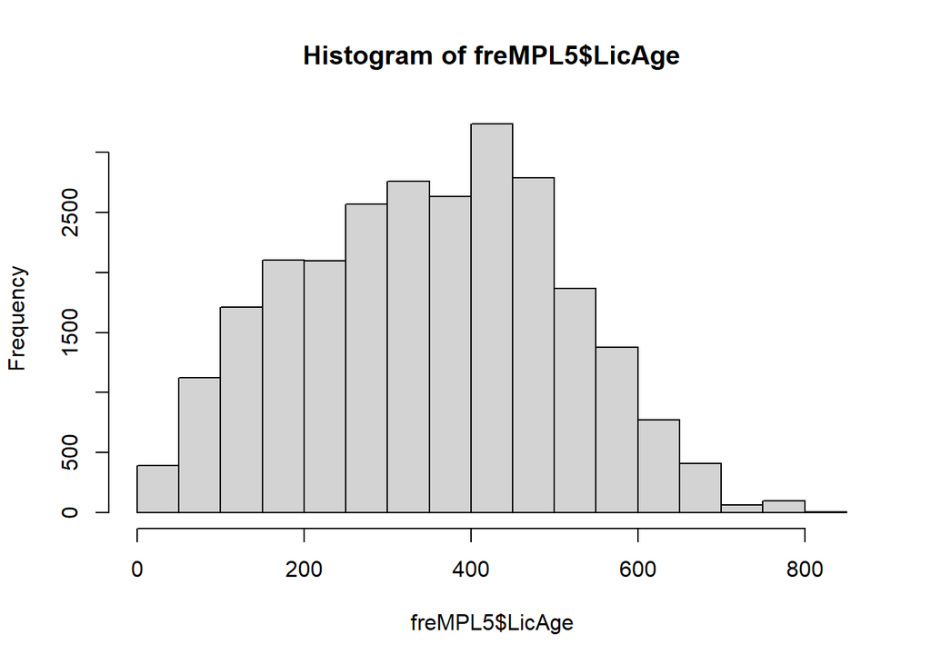

```r
hist(freMPL5$LicAge)
```

```r
summary(freMPL5$LicAge[freMPL5$ClaimInd == 0])
```

```
##    Min. 1st Qu.  Median    Mean 3rd Qu.    Max.
##    24.0   230.0   357.0   351.7   465.0   821.0
```

```r
summary(freMPL5$LicAge[freMPL5$ClaimInd == 1])
```

```
##    Min. 1st Qu.  Median    Mean 3rd Qu.    Max.
##    24.0   216.0   334.0   333.5   451.0   844.0
```

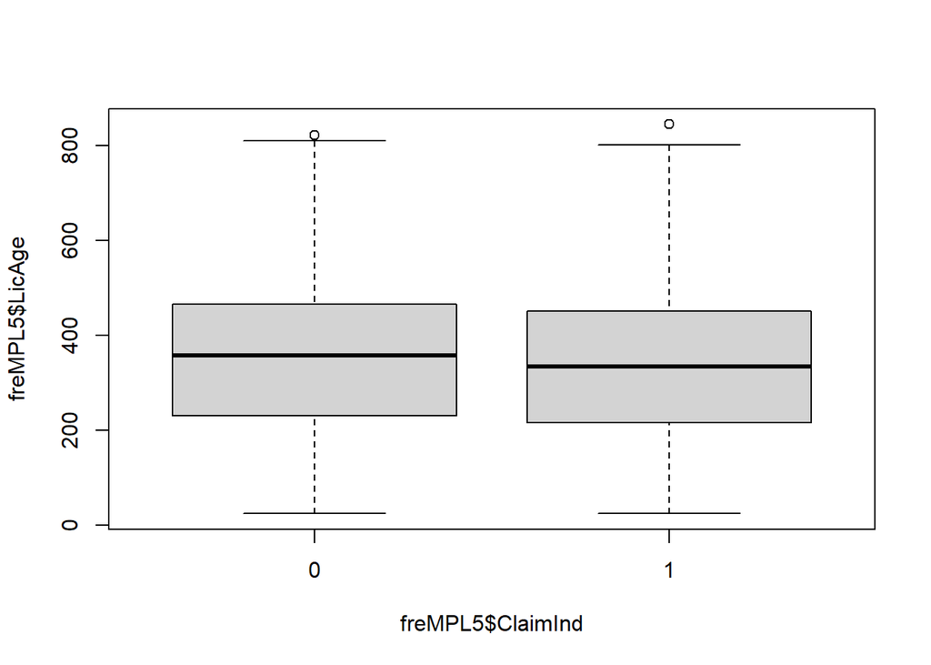

```r
boxplot(freMPL5$LicAge ~ freMPL5$ClaimInd)
```

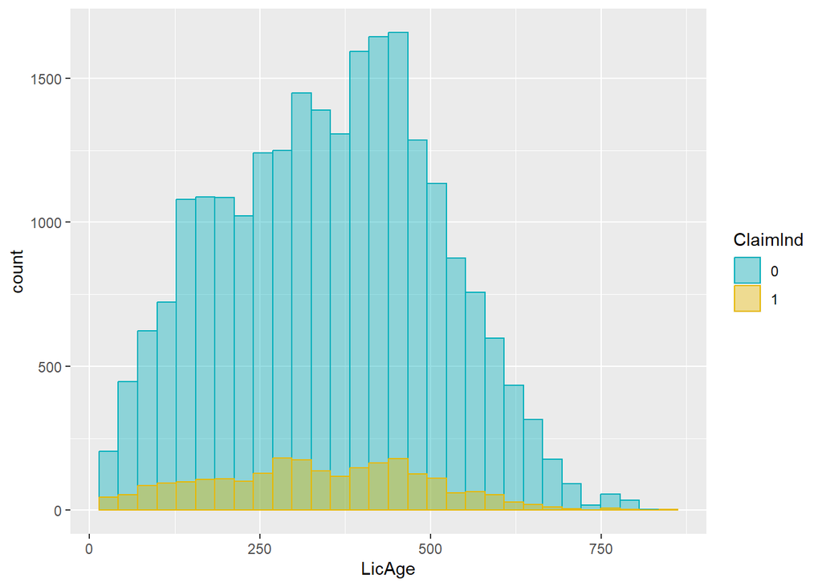

```r
ggplot(freMPL5, aes(x = LicAge)) +
  geom_histogram(aes(color = ClaimInd, fill = ClaimInd),
                position = "identity", bins = 30, alpha = 0.4) +
  scale_color_manual(values = c("#00AFBB", "#E7B800")) +
  scale_fill_manual(values = c("#00AFBB", "#E7B800"))
```

On retrouve à peu près les mêmes résultats ici que pour DrivAge. L’interprétation est la même.

##### Etude par rapport au coût

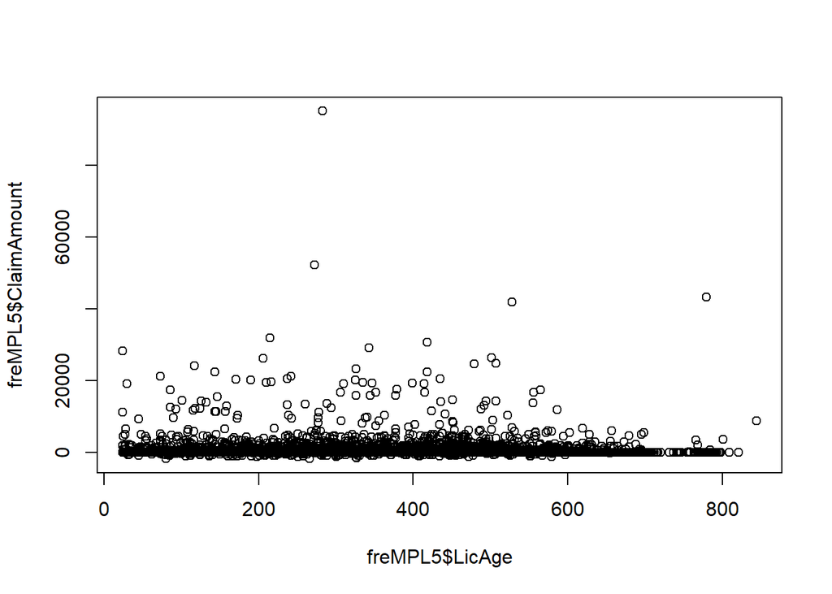

```r
plot(freMPL5$ClaimAmount ~ freMPL5$LicAge)
```

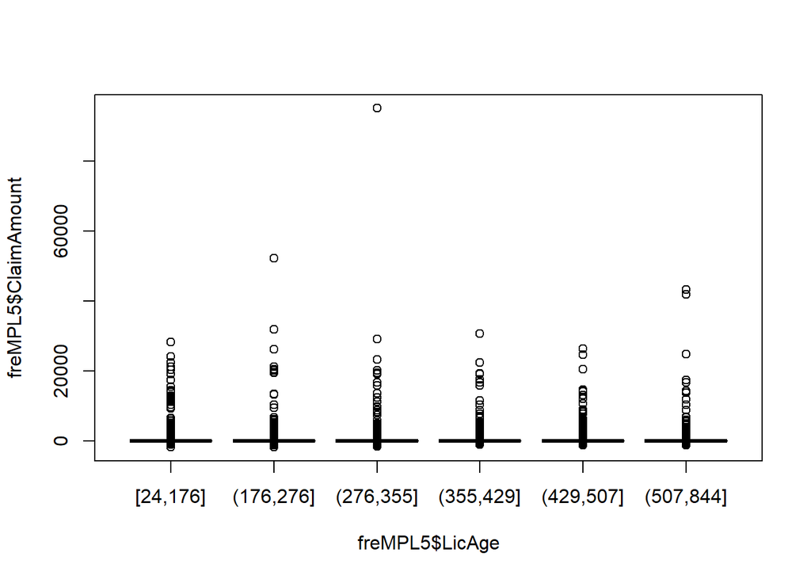

```r
freMPL5$LicAge <- cut(freMPL5$LicAge, quantile(freMPL5$LicAge, probs = seq(0,1,1/6)), include.lowest = TRUE)
boxplot(freMPL5$ClaimAmount ~ freMPL5$LicAge)
```

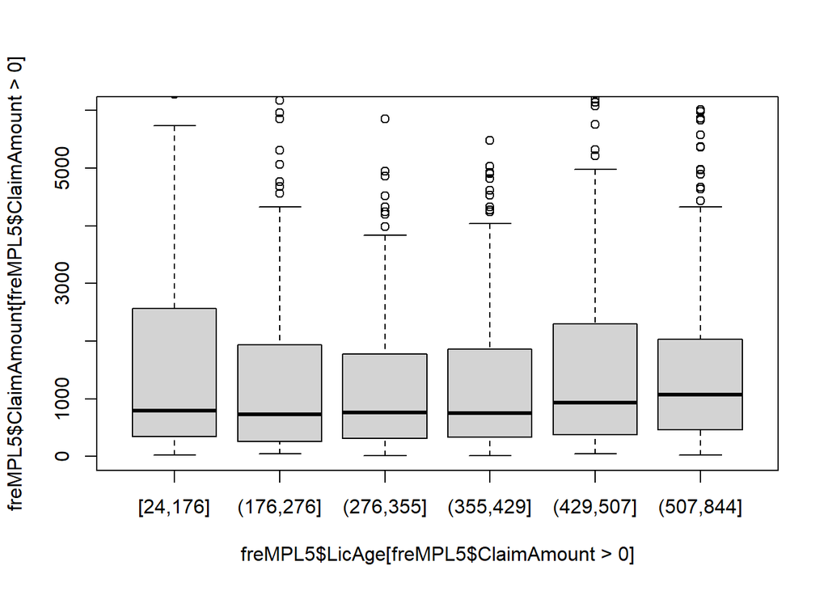

```r
boxplot(freMPL5$ClaimAmount[freMPL5$ClaimAmount>0] ~ freMPL5$LicAge[freMPL5$ClaimAmount>0], ylim=c(0,6000))
```

Idem que pour l’âge.

### Création d’une variable (ObtLic)

```r
#Rappel de la formule :
#freMPL5$ObtLic <- freMPL5$DrivAge - freMPL5$LicAge/12
summary(freMPL5$ObtLic)
```

```
##    Min. 1st Qu.  Median    Mean 3rd Qu.    Max.
##   16.00   19.00   20.00   21.74   23.00   63.00
```

On a des dates d’obtention de permis de 16 ans ? Ceci est étrange… Il faudra regarder dans les données :

```r
sum(ifelse(freMPL5$ObtLic<18,1,0))
```

```
## [1] 13
```

Il n’y a que 13 valeurs incohérente, ce qui ne devrait pas beaucoup modifier l’analyse. Nous laisserons donc les données comme tel.

##### Etude par rapport à la sinistralité

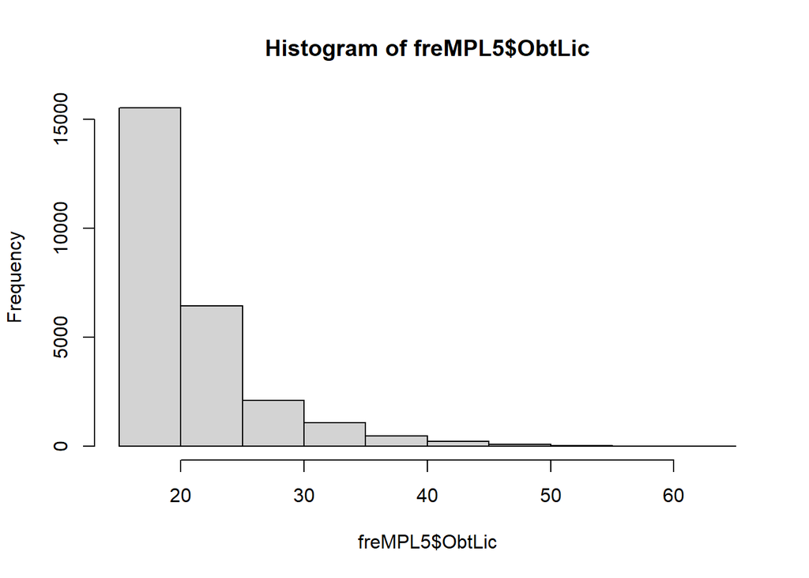

```r
hist(freMPL5$ObtLic)
```

```r
summary(freMPL5$ObtLic[freMPL5$ClaimInd == 0])
```

```
##    Min. 1st Qu.  Median    Mean 3rd Qu.    Max.
##   16.00   19.00   20.00   21.76   23.00   63.00
```

```r
summary(freMPL5$ObtLic[freMPL5$ClaimInd == 1])
```

```
##    Min. 1st Qu.  Median    Mean 3rd Qu.    Max.
##   17.00   18.00   20.00   21.56   22.00   62.00
```

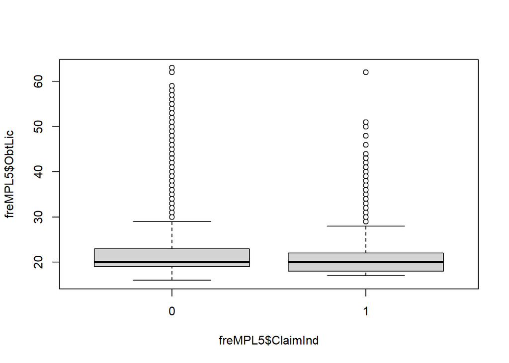

```r
boxplot(freMPL5$ObtLic ~ freMPL5$ClaimInd)
```

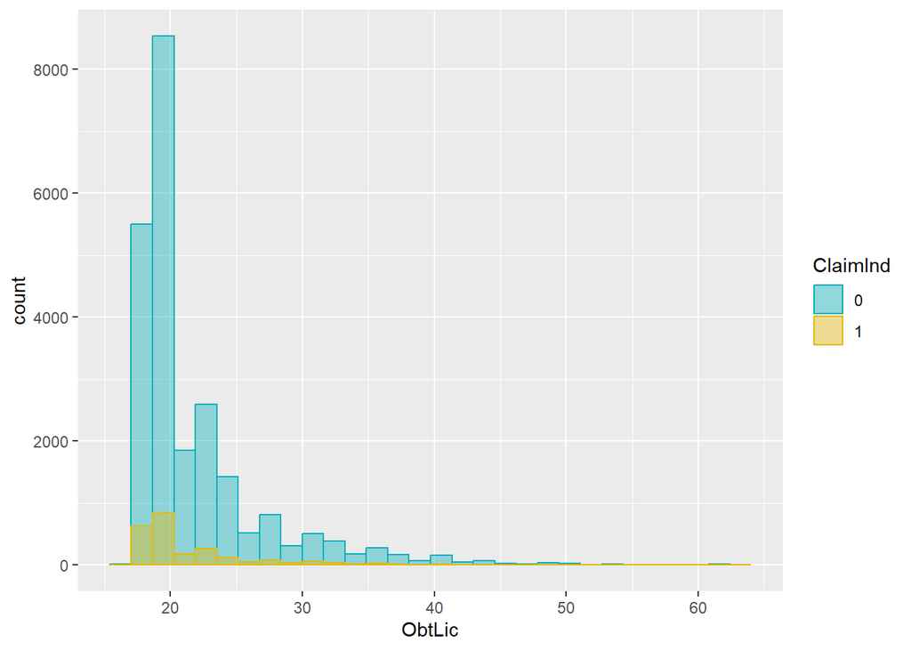

```r
ggplot(freMPL5, aes(x = ObtLic)) +
  geom_histogram(aes(color = ClaimInd, fill = ClaimInd),
                position = "identity", bins = 30, alpha = 0.4) +
  scale_color_manual(values = c("#00AFBB", "#E7B800")) +
  scale_fill_manual(values = c("#00AFBB", "#E7B800"))
```

Il ne semble pas y avoir ici d’impact particulier.

##### Etude par rapport au coût

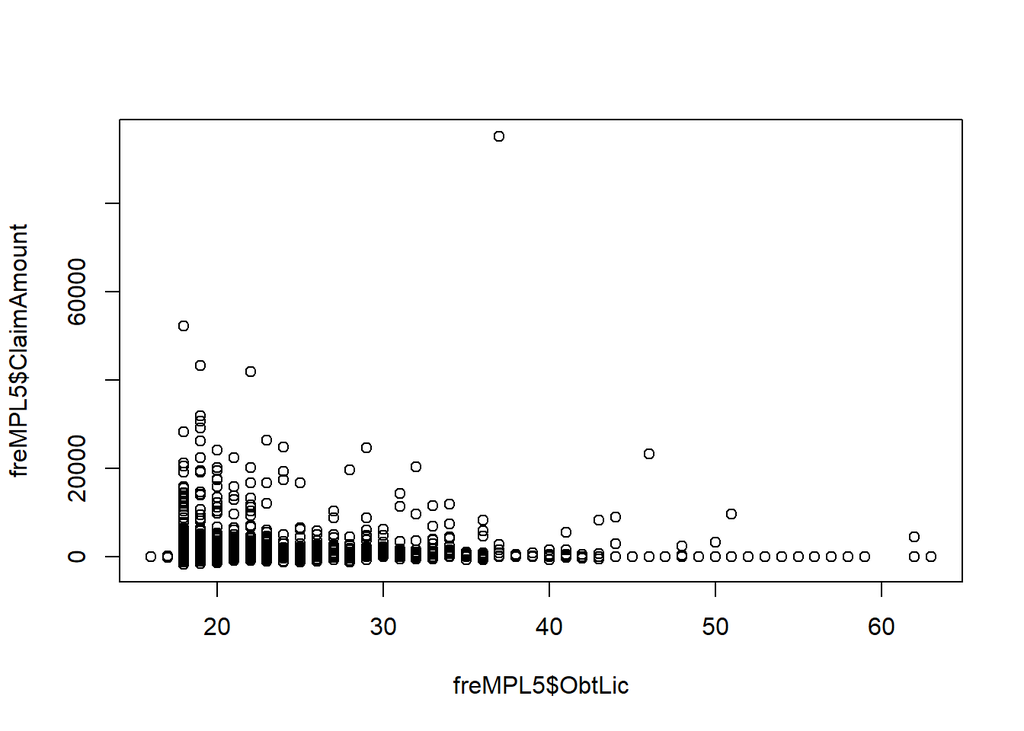

```r
plot(freMPL5$ClaimAmount ~ freMPL5$ObtLic)
```

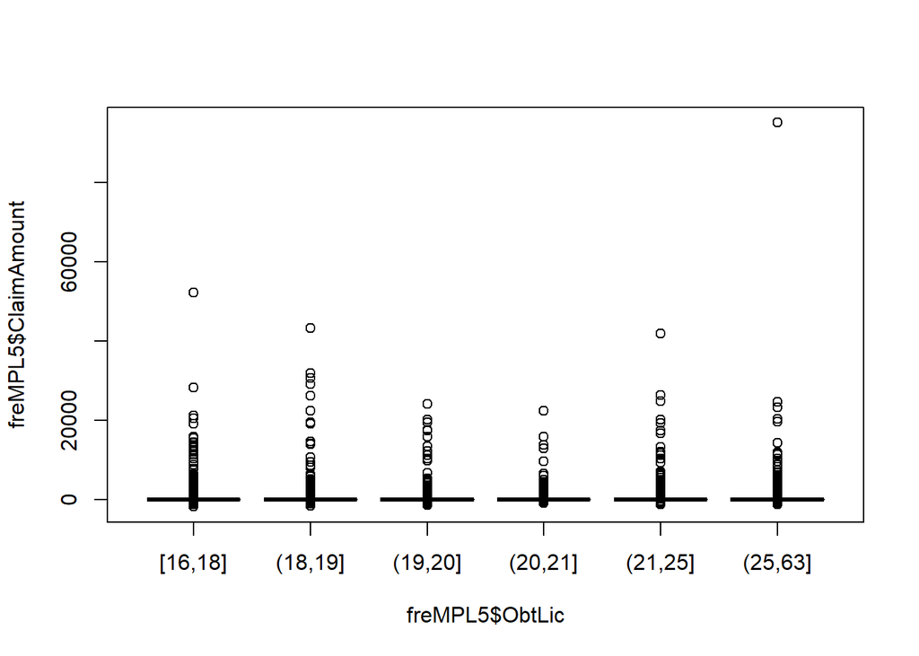

```r
freMPL5$ObtLic <- cut(freMPL5$ObtLic, quantile(freMPL5$ObtLic, probs = seq(0,1,1/6)), include.lowest = TRUE)
boxplot(freMPL5$ClaimAmount ~ freMPL5$ObtLic)
```

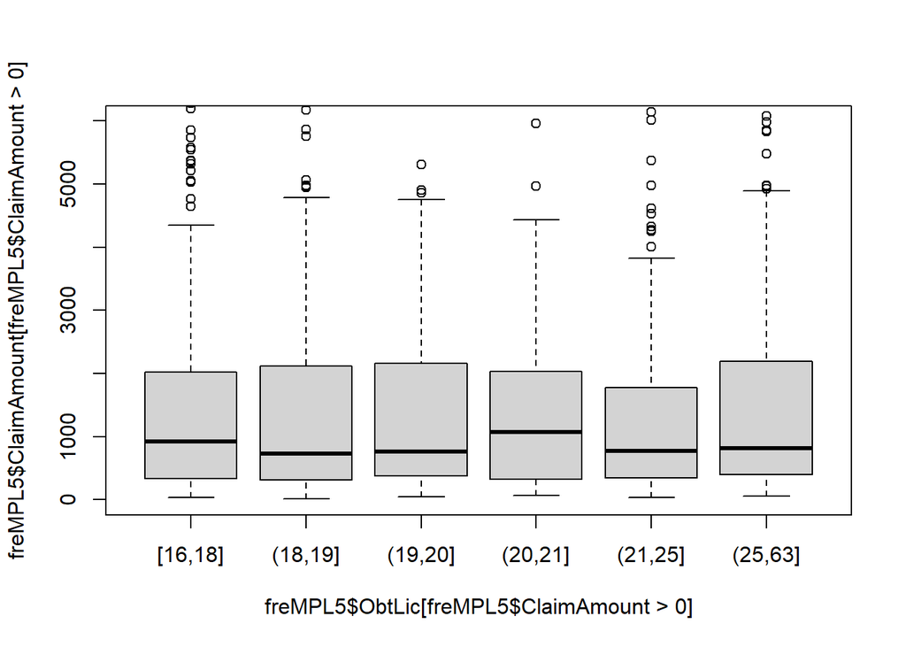

```r
boxplot(freMPL5$ClaimAmount[freMPL5$ClaimAmount>0] ~ freMPL5$ObtLic[freMPL5$ClaimAmount>0], ylim=c(0,6000))
```

Il n’y a pas de claire tendance une nouvelle fois. Cette variable ne sera sûrement pas utile par la suite.

### Exposition

### Date de début

### Date de fin

### Genre

### Statut marital

### CSP

Cette catégorie devra être regroupée car elle contient trop de modalités de facteur.

### Utilisation du véhicule

### Limite kilométrique

### Zone de risque

Cette catégorie devra être regroupée (idem CSP)

### Accident responsable

### Accident non-responsable

### Parking

### Incendie ou vol

### Bris de glace

### Panne

### Etude de la variables coût

##### …en fonction de la sinistralité

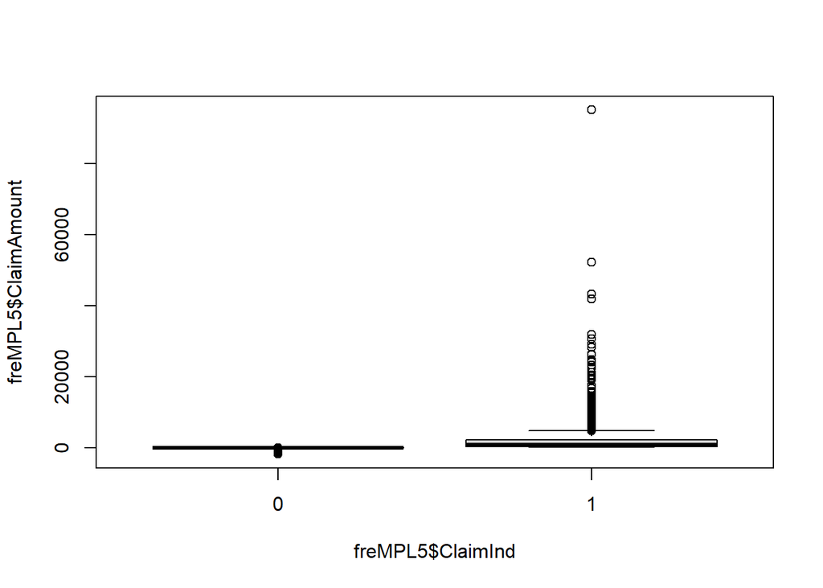

```r
plot(freMPL5$ClaimAmount ~ freMPL5$ClaimInd)
```

```r
summary(freMPL5$ClaimAmount[freMPL5$ClaimInd == 1]) #resumé lorsque de l'argent est demandé
```

```
##     Min.  1st Qu.   Median     Mean  3rd Qu.     Max.
##     8.84   345.71   800.95  2277.22  2089.58 95150.96
```

```r
summary(freMPL5$ClaimAmount[freMPL5$ClaimInd == 0])
```

```
##      Min.   1st Qu.    Median      Mean   3rd Qu.      Max.
## -1842.014     0.000     0.000    -7.584     0.000     0.000
```

On remarque donc l’apparition de quelques données étranges. En effet, on a l’apparition de variables de coût négatives. Ceci est du à une régularisation. ne pouvant pas traiter cela, nous supprimerons les lignes correspondantes qui sont au nombre de 278.

```r
sum(ifelse(freMPL5$ClaimAmount[freMPL5$ClaimInd == 0]<0,1,0)) #=278
```

```
## [1] 278
```

Nous supprimons alors les lignes en questions :

```r
freMPL5 <- subset(freMPL5, freMPL5$ClaimAmount >= 0)
```

Nous avons autrement une distribution des coût qui est relativement proche de 0 avec tout de même l’apparition de quelques sinistres graves qui faussent la moyenne :

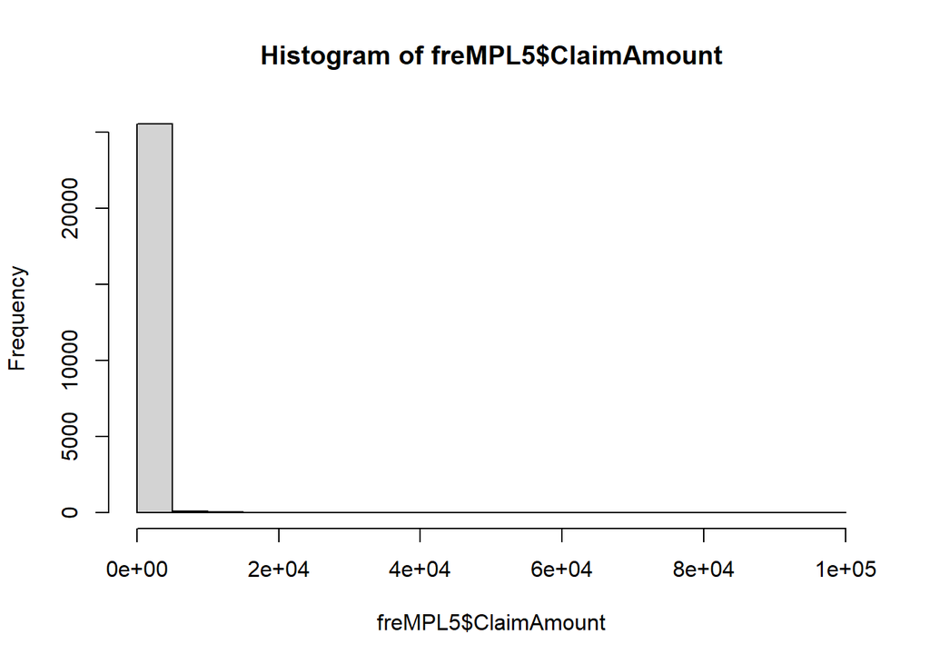

```r
hist(freMPL5$ClaimAmount) #écrasé par 0 car il y a énormément de petits sinistres
```

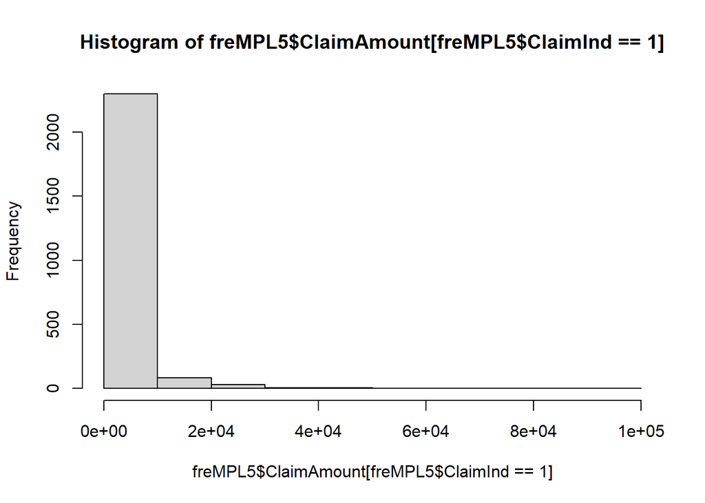

```r
hist(freMPL5$ClaimAmount[freMPL5$ClaimInd == 1]) #de nouveau écrasé dans les petites valeurs
```

Pour mieux voir la potentielle distribution, nous allons essayer de zoomer vers les petites valeurs :

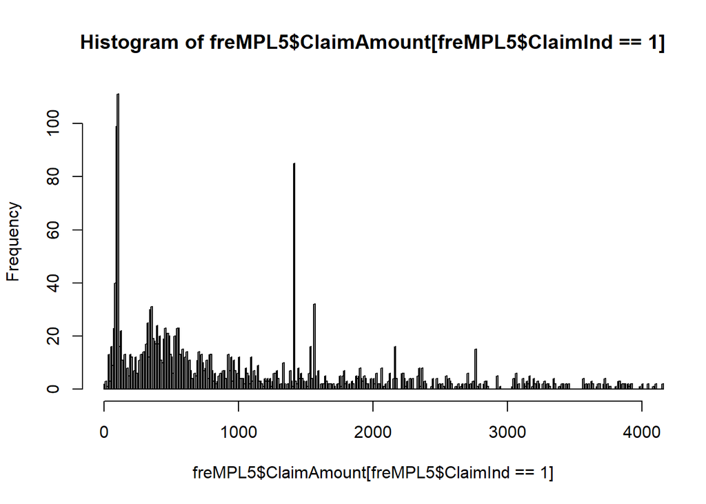

```r
hist(freMPL5$ClaimAmount[freMPL5$ClaimInd == 1], breaks=seq(0,100000,10),xlim=c(0,4000))
```

On a ici un graphique plus intéressant qui nous permettra de proposer éventuellement une loi pour la variable de coût. On remarque tout de fois quelques énormes pics de fréquence. Nous pouvons imaginer qu’il s’agit d’une dépense forfaitaire (comme par exemple un bris de glace qui s’en rapproche à cause de Carglass en France).

On remarque un premier pic entre 90 et 110 et un autre 1410 et 1420. Regardons à quoi cela pourrait être dû :

```r
summary(freMPL5[freMPL5$ClaimAmount<110 & freMPL5$ClaimAmount>90,])
```

```
##     Exposure            LicAge     RecordBeg            RecordEnd
##  Min.   :0.0540   [24,176] :42   Min.   :2004-01-01   Min.   :2004-01-21
##  1st Qu.:0.4610   (176,276]:38   1st Qu.:2004-01-01   1st Qu.:2004-07-01
##  Median :0.6565   (276,355]:44   Median :2004-03-26   Median :2004-10-02
##  Mean   :0.6222   (355,429]:29   Mean   :2004-04-03   Mean   :2004-09-04
##  3rd Qu.:0.8330   (429,507]:38   3rd Qu.:2004-06-03   3rd Qu.:2004-11-15
##  Max.   :1.0000   (507,844]:19   Max.   :2004-11-22   Max.   :2004-12-27
##                                                       NA's   :131
##     Gender     MariStat     SocioCateg                    VehUsage
##  Female: 67   Alone: 24   CSP50  :120   Private               : 53
##  Male  :143   Other:186   CSP60  : 31   Private+trip to office:112
##                           CSP55  : 28   Professional          : 39
##                           CSP1   :  6   Professional run      :  6
##                           CSP42  :  6
##                           CSP48  :  6
##                           (Other): 13
##     DrivAge   HasKmLimit  ClaimAmount     ClaimNbResp ClaimNbNonResp
##  [20,35]:46   0:199      Min.   : 90.02   0:157       0      :140
##  (35,43]:38   1: 11      1st Qu.: 97.32   1: 48       1      : 63
##  (43,51]:44              Median :102.59   2:  3       2      :  7
##  (51,57]:28              Mean   : 99.60   3:  2       3      :  0
##  (57,65]:32              3rd Qu.:102.59   4:  0       4      :  0
##  (65,95]:22              Max.   :109.51               5      :  0
##                                                       (Other):  0
##  ClaimNbParking ClaimNbFireTheft ClaimNbWindscreen OutUseNb    RiskArea
##  0:197          0:205            0      :119       0:168    7      :53
##  1: 13          1:  5            1      : 71       1: 27    10     :36
##  2:  0          2:  0            2      : 12       2:  6    9      :32
##  3:  0          3:  0            3      :  8       3:  4    6      :25
##  4:  0                           4      :  0       4:  4    11     :22
##                                  5      :  0       5:  1    5      :16
##                                  (Other):  0                (Other):26
##    BonusMalus    ClaimInd     ObtLic
##  Min.   : 50.0   0:  0    [16,18]:65
##  1st Qu.: 50.0   1:210    (18,19]:51
##  Median : 50.0            (19,20]:24
##  Mean   : 58.9            (20,21]:15
##  3rd Qu.: 67.0            (21,25]:28
##  Max.   :100.0            (25,63]:27
##
```

On remarque que cette tranche représente 8,7% des assurés qui ont eu recours à un remboursement.

### Etude de la variable d’indication de remboursement

```r
summary(freMPL5[freMPL5$ClaimInd == 0,])
```

```
##     Exposure            LicAge       RecordBeg            RecordEnd
##  Min.   :0.0010   [24,176] :3815   Min.   :2004-01-01   Min.   :2004-01-02
##  1st Qu.:0.1660   (176,276]:3915   1st Qu.:2004-01-01   1st Qu.:2004-04-26
##  Median :0.3470   (276,355]:3805   Median :2004-04-28   Median :2004-07-07
##  Mean   :0.4024   (355,429]:3898   Mean   :2004-05-12   Mean   :2004-07-16
##  3rd Qu.:0.6110   (429,507]:3873   3rd Qu.:2004-09-01   3rd Qu.:2004-10-08
##  Max.   :1.0000   (507,844]:3998   Max.   :2004-12-31   Max.   :2004-12-31
##                                                         NA's   :11478
##     Gender       MariStat       SocioCateg                      VehUsage
##  Female: 7903   Alone: 3058   CSP50  :11008   Private               : 7818
##  Male  :15401   Other:20246   CSP60  : 5171   Private+trip to office:10915
##                               CSP55  : 2964   Professional          : 3735
##                               CSP1   :  833   Professional run      :  836
##                               CSP66  :  579
##                               CSP42  :  573
##                               (Other): 2176
##     DrivAge     HasKmLimit  ClaimAmount ClaimNbResp ClaimNbNonResp
##  [20,35]:4270   0:21505    Min.   :0    0:18106     0      :17391
##  (35,43]:3490   1: 1799    1st Qu.:0    1: 4453     1      : 4788
##  (43,51]:3978              Median :0    2:  656     2      :  902
##  (51,57]:4026              Mean   :0    3:   73     3      :  183
##  (57,65]:3624              3rd Qu.:0    4:   16     4      :   36
##  (65,95]:3916              Max.   :0                5      :    2
##                                                     (Other):    2
##  ClaimNbParking ClaimNbFireTheft ClaimNbWindscreen OutUseNb     RiskArea
##  0:21600        0:21717          0      :15831     0:19996   7      :5531
##  1: 1554        1: 1456          1      : 5783     1: 2241   10     :4105
##  2:  128        2:  115          2      : 1379     2:  589   6      :3493
##  3:   18        3:   16          3      :  240     3:  266   9      :3432
##  4:    4                         4      :   54     4:  133   11     :2649
##                                  6      :    8     5:   79   5      :1381
##                                  (Other):    9               (Other):2713
##    BonusMalus     ClaimInd      ObtLic
##  Min.   : 50.00   0:23304   [16,18]:5437
##  1st Qu.: 50.00   1:    0   (18,19]:5631
##  Median : 50.00             (19,20]:2827
##  Mean   : 57.55             (20,21]:1818
##  3rd Qu.: 60.00             (21,25]:3982
##  Max.   :185.00             (25,63]:3609
##
```

```r
summary(freMPL5[freMPL5$ClaimInd == 1,])
```

```
##     Exposure            LicAge      RecordBeg            RecordEnd
##  Min.   :0.0020   [24,176] :459   Min.   :2004-01-01   Min.   :2004-01-12
##  1st Qu.:0.4160   (176,276]:405   1st Qu.:2004-01-01   1st Qu.:2004-07-01
##  Median :0.6110   (276,355]:451   Median :2004-02-27   Median :2004-09-12
##  Mean   :0.6026   (355,429]:379   Mean   :2004-03-21   Mean   :2004-08-26
##  3rd Qu.:0.8190   (429,507]:411   3rd Qu.:2004-05-21   3rd Qu.:2004-11-01
##  Max.   :1.0000   (507,844]:313   Max.   :2004-12-28   Max.   :2004-12-31
##                                                        NA's   :1197
##     Gender      MariStat      SocioCateg                     VehUsage
##  Female: 843   Alone: 348   CSP50  :1228   Private               : 672
##  Male  :1575   Other:2070   CSP60  : 430   Private+trip to office:1111
##                             CSP55  : 246   Professional          : 516
##                             CSP1   : 123   Professional run      : 119
##                             CSP46  :  83
##                             CSP66  :  80
##                             (Other): 228
##     DrivAge    HasKmLimit  ClaimAmount       ClaimNbResp ClaimNbNonResp
##  [20,35]:496   0:2284     Min.   :    8.84   0:1757      0      :1661
##  (35,43]:403   1: 134     1st Qu.:  345.71   1: 553      1      : 604
##  (43,51]:453              Median :  800.95   2:  89      2      : 125
##  (51,57]:365              Mean   : 2277.22   3:  19      3      :  21
##  (57,65]:370              3rd Qu.: 2089.58   4:   0      4      :   4
##  (65,95]:331              Max.   :95150.96               5      :   2
##                                                          (Other):   1
##  ClaimNbParking ClaimNbFireTheft ClaimNbWindscreen OutUseNb    RiskArea
##  0:2192         0:2206           0      :1577      0:2016   7      :503
##  1: 199         1: 193           1      : 604      1: 266   10     :461
##  2:  27         2:  19           2      : 182      2:  77   9      :356
##  3:   0         3:   0           3      :  40      3:  32   11     :332
##  4:   0                          4      :  11      4:  21   6      :323
##                                  5      :   4      5:   6   5      :142
##                                  (Other):   0               (Other):301
##    BonusMalus     ClaimInd     ObtLic
##  Min.   : 50.00   0:   0   [16,18]:628
##  1st Qu.: 50.00   1:2418   (18,19]:568
##  Median : 50.00            (19,20]:279
##  Mean   : 59.69            (20,21]:184
##  3rd Qu.: 65.00            (21,25]:391
##  Max.   :156.00            (25,63]:368
##
```

On remarque que LicAge et DrivAge réduisent le risque d’avoir un sinistre.

De même, plus le score de malus est haut et plus l’assuré a de risque d’avoir un sinistre.

Avoir une limite de kilomètres semblent aussi réduire les risques.

Pour les catégories sociaux-professionnelles, il faudra faire une étude plus poussée avant de conclure.